# STA 141A: Predicting Wildfire Incidence in the United States

Abirami Valliammai Kathiresan

### Abstract

The goal of this report is to develop a predictive model to forecast notable wildfire activity across the US. Data from historical wildfire records was restructured into a grid-by-month data set where each observation is represented as a 1° × 1° latitude-longitude grid cell and month. The outcome indicates whether a notable wildfire will occur in the next month. Firstly, the dataset will be pre-processed in order to transform the observations in space-time units and construct predictors. Next, exploratory data analysis will be used to understand the underlying spatial and temporal trends associated with the wildfire data. This information will be used to create a baseline logistic regression model and an XGBoost model to predict the wildfire outcomes. The model performance will be evaluated and compared using the AUC (Area under the ROC Curve). The results indicate that the XGBoost model outperforms the logistic regression model and improves the predictive performance by around 10.85% in AUC.

### Introduction

Throughout the US, wildfires have been a prevalent natural disaster that cause significant damage, economic loss, and put humans at risk every year. Wildfire activity has evolved over time in terms of severity and frequency, so it is important to create accurate predictive models to forecast future wildfire activity. Through better prediction, wildfire risk management procedures can be improved and it is easier to prepare for significant wildfire activity. This project aims to construct predictive models that estimate the chance of a notable wildfire occurring during a certain month for a given geographic location. The data is aggregated into space-time units in a panel dataset and will be fitted in a logistic regression baseline model and gradient boosting model to capture the complex interactions between predictors. Then, the models are compared and evaluated using Area Under the ROC Curve (AUC).

### 1. Data Preprocessing

The data preprocessing portion of this report will focus on transforming the raw wildfire data into a data set that is clean, structured, and usable for the necessary tasks. For instance, the spatial and temporal units will be clearly defined, notable fires will be identified, the binary outcome variable is fixed, and missing or unusual data is handled. The final data set will ensure that there is one record for each grid cell and month as well as a binary outcome.

#### Load Data

Firstly, the data is loaded with several key variables: `FIRE_YEAR`: Calendar year when the fire was discovered, `DISCOVERY_DOY`: The day of the year when the fire was discovered, `FIRE_SIZE`: The final size of the fire in acres, `LATITUDE` and `LONGITUDE`: The ignition location in decimal degrees, `STATE`: State in which the fire burned, `STAT_CAUSE_DESCR`: The reason why the wildfire occurred, `CONT_DOY`: The day of the year that the fire persisted until, `OWNER_DESCR`: The owner of the land where the fire occurred. Here is an overview of the loaded variables:

```
## Rows: 100,000
## Columns: 9
## $ FIRE_YEAR        <int> 2004, 2005, 2005, 2005, 2005, 2005, 2005, 2005, 2005,…
## $ DISCOVERY_DOY    <int> 277, 186, 182, 147, 202, 148, 172, 107, 108, 199, 117…
## $ FIRE_SIZE        <dbl> 0.10, 0.10, 3.00, 0.10, 0.10, 0.10, 0.50, 12.00, 5.00…
## $ LATITUDE         <dbl> 38.56417, 48.40778, 48.89444, 37.04417, 36.90000, 33.…
## $ LONGITUDE        <dbl> -120.54222, -115.55778, -115.16528, -119.34389, -107.…
## $ STATE            <fct> CA, MT, MT, CA, NM, AZ, AZ, MN, TX, AZ, AZ, AZ, NM, C…
## $ STAT_CAUSE_DESCR <chr> "Lightning", "Campfire", "Miscellaneous", "Equipment …
## $ CONT_DOY         <int> 277, 186, 182, 147, 203, 148, 172, 107, 108, 200, 117…
## $ OWNER_DESCR      <chr> "USFS", "STATE OR PRIVATE", "STATE OR PRIVATE", "STAT…
```

#### Temporal Patterns

`FIRE_YEAR` and `DISCOVERY_DOY` will be converted to `FIRE_DATE` in order to extract the year and month of the fire for later analysis.

#### Notable Fire Threshold

The original wildfire dataset has rows of information with fires of various sizes, but a majority of those fires are small in size and insignificant. Therefore, to ensure that these small fires will not obscure meaningful fire data or introduce a class imbalance, the data set has been reduced to notable fires, which are defined as burned for 300 acres or more. Similarly, U.S. fire management agencies define large fires as 100 acres for timber fuel models and 300 acres for grass or brush fuel models. Therefore, all wildfire records that contain `FIRE_SIZE` >= 300 acres will be kept in the data set for analysis. The number of notable fires is as follows:

```
## Number of notable fires: 1381
```

#### Spatial Patterns

The spatial units that will be used are a latitude-longitude 1° × 1° grid. Event-level fire records will be converted into a grid and month summary with a binary indicator. The 1° × 1° latitude-longitude grid cells will be used along with months for the time-space units because the grid ensures that the spatial units are consistent and specific, rather than a larger spacial unit like State, which is more general and broad. Also, due to reporting errors, latitude and longitude pairs might not be accurate, so the grid will smooth out the noise and capture the wildfire activity in that cell rather than the precise locations. This spatial unit will provide a good balance for determining accurate and specific spatial patterns. Here is an overview of the grid cells by latitude, longitude, year-month index, number of fires, and whether a fire occurred this month or not:

```
## # A tibble: 6 × 5
##   lat_bin lon_bin     ym n_fires fire_this_month
##     <dbl>   <dbl>  <dbl>   <int>           <dbl>
## 1      17     -67 200407       1               1
## 2      18     -68 200906       1               1
## 3      18     -67 200503       1               1
## 4      19    -156 199210       1               1
## 5      19    -156 199910       1               1
## 6      19    -156 200706       1               1
```

Additionally, a complete (grid, month) panel will be created that indicates the outcome of whether a fire occurred or not. There will be a balanced panel with the grid cells that have at least one notable fire in grid_month_fire and all the months within the given year, or the range of `ym`. This is an overview of the (grid, month) panel:

```
## Rows: 148,092
## Columns: 7
## $ lat_bin         <dbl> 17, 17, 17, 17, 17, 17, 17, 17, 17, 17, 17, 17, 17, 17…
## $ lon_bin         <dbl> -67, -67, -67, -67, -67, -67, -67, -67, -67, -67, -67,…
## $ ym              <dbl> 199201, 199202, 199203, 199204, 199205, 199206, 199207…
## $ year            <dbl> 1992, 1992, 1992, 1992, 1992, 1992, 1992, 1992, 1992, …
## $ month           <dbl> 1, 2, 3, 4, 5, 6, 7, 8, 9, 10, 11, 12, 1, 2, 3, 4, 5, …
## $ n_fires         <int> 0, 0, 0, 0, 0, 0, 0, 0, 0, 0, 0, 0, 0, 0, 0, 0, 0, 0, …
## $ fire_this_month <dbl> 0, 0, 0, 0, 0, 0, 0, 0, 0, 0, 0, 0, 0, 0, 0, 0, 0, 0, …
```

#### Prediction Target

There is a binary indicator variable that represents the outcome for the fire in the next month for each (grid, month) space-time unit. If `y_next` = 1, then there is a notable fire that occurs in that grid cell in the next month and if `y_next` = 0 then no notable fire occurs. The predictive model will predict for this outcome binary indicator variable to forecast whether a notable wildfire will take place in the following month. Here is the number of notable fires (1) and non-notable (0) fires in the dataset:

```
##
##      0      1
## 146265   1311
```

#### Baseline Predictors

The first predictor that will be used is `state`, which represents the US State in which the fire occurred. If there are multiple states that occurred in the grid, then the majority state is chosen. Here is the summary statistics for the frequency of each `state` in the dataset.

```
##      state
##  AK     :17732
##  TX     :16016
##  CA     :10582
##  NM     : 8294
##  MT     : 8294
##  OR     : 6578
##  (Other):80080
```

The second predictor that will be used is seasonality, in terms of `month_sin` and `month_cos`. The months in the data set are represented numerically, so they are converted into sine and cosine features so that months that are further apart, like December and January, are also close numerically. This ensures that the month variable is accounted for properly in the final models. Here are the values for `month_sin` and `month_cos`.

```
## # A tibble: 6 × 2
##   month_sin month_cos
##       <dbl>     <dbl>
## 1  5   e- 1  8.66e- 1
## 2  8.66e- 1  5   e- 1
## 3  1   e+ 0  6.12e-17
## 4  8.66e- 1 -5   e- 1
## 5  5   e- 1 -8.66e- 1
## 6  1.22e-16 -1   e+ 0
```

```
##     n_fires           fire_lag12         fire_roll3       fire_roll12
##  Min.   :0.000000   Min.   :0.000000   Min.   :0.00000   Min.   :0.0000
##  1st Qu.:0.000000   1st Qu.:0.000000   1st Qu.:0.00000   1st Qu.:0.0000
##  Median :0.000000   Median :0.000000   Median :0.00000   Median :0.0000
##  Mean   :0.009351   Mean   :0.008972   Mean   :0.02798   Mean   :0.1093
##  3rd Qu.:0.000000   3rd Qu.:0.000000   3rd Qu.:0.00000   3rd Qu.:0.0000
##  Max.   :3.000000   Max.   :3.000000   Max.   :5.00000   Max.   :6.0000
##    size_roll3        size_roll12
##  Min.   :     0.0   Min.   :     0
##  1st Qu.:     0.0   1st Qu.:     0
##  Median :     0.0   Median :     0
##  Mean   :   129.7   Mean   :   497
##  3rd Qu.:     0.0   3rd Qu.:     0
##  Max.   :344833.0   Max.   :344833
```

The fourth predictor that will be used is the fire cause, which will indicate what the category the fire cause belongs to. For instance, causes like campfire and arson are caused by humans while lightning is a natural cause. The various causes produce wildfires with different behaviors, so this predictor will be helpful to understand the differences between the trends of human and natural wildfire causes, improving the model’s ability to predict wildfire incidence. This set of predictors will be represented as `natural_fires`, `human_fires`, and `infrastructure_fires`. Here are the possible types of fire causes and summary statistics for each of the constructed variables:

```
##  [1] "Lightning"         "Campfire"          "Miscellaneous"
##  [4] "Equipment Use"     "Arson"             "Children"
##  [7] "Debris Burning"    "Smoking"           "Railroad"
## [10] "Structure"         "Powerline"         "Fireworks"
## [13] "Missing/Undefined"
```

```
##  natural_fires       human_fires       infrastructure_fires
##  Min.   :0.000000   Min.   :0.000000   Min.   :0.0000000
##  1st Qu.:0.000000   1st Qu.:0.000000   1st Qu.:0.0000000
##  Median :0.000000   Median :0.000000   Median :0.0000000
##  Mean   :0.003605   Mean   :0.002988   Mean   :0.0002643
##  3rd Qu.:0.000000   3rd Qu.:0.000000   3rd Qu.:0.0000000
##  Max.   :3.000000   Max.   :2.000000   Max.   :1.0000000
```

Next, the fifth predictor is the average duration of the wildfire represented as `avg_fire_duration`. The average duration of a wildfire indicates the type of conditions and environment during that time period. For instance, a longer fire means that there is a higher probability of a wildfire occurring again due to temporal trends like hot or low humidity conditions, which can extend into future months. Here is the summary statistics for the average fire duration.

```
##  avg_fire_duration
##  Min.   :  0.00000
##  1st Qu.:  0.00000
##  Median :  0.00000
##  Mean   :  0.08665
##  3rd Qu.:  0.00000
##  Max.   :164.00000
```

The sixth predictor that will be used is land ownership type because the different types of land owners will manage land differently, impacting wildfire trends. For instance, lands that are managed by private owners may have higher incidence of fires linked to humans while federal owners may have a higher probability of a fire occurring due to the environment in forest ecosystems. This set of predictors will be represented as `federal_fires`, `public_fires`, and `private_fires`. Here are the possible values for the type of land ownership and the summary statistics for each of the constructed variables:

```
##  [1] "USFS"                  "STATE OR PRIVATE"      "MISSING/NOT SPECIFIED"
##  [4] "OTHER FEDERAL"         "BIA"                   "STATE"
##  [7] "PRIVATE"               "TRIBAL"                "FWS"
## [10] "BLM"                   "NPS"                   "BOR"
## [13] "MUNICIPAL/LOCAL"       "COUNTY"                "UNDEFINED FEDERAL"
```

```
##  federal_fires      private_fires       public_fires
##  Min.   :0.000000   Min.   :0.000000   Min.   :0.000000
##  1st Qu.:0.000000   1st Qu.:0.000000   1st Qu.:0.000000
##  Median :0.000000   Median :0.000000   Median :0.000000
##  Mean   :0.003666   Mean   :0.001775   Mean   :0.001105
##  3rd Qu.:0.000000   3rd Qu.:0.000000   3rd Qu.:0.000000
##  Max.   :3.000000   Max.   :2.000000   Max.   :2.000000
```

#### Dataset Summary Table

Here is an overview of the dataset:

Outcome: Binary outcome depending on whether a notable fire occurs in the grid cell next month

Predictors:

This is a summary table that indicates the key attributes and characteristics of the data set:

| Number_Rows | Min_Year | Max_Year | Space_Unit | Time_Unit | Outcome | Predictors |
| --- | --- | --- | --- | --- | --- | --- |
| 147576 | 1992 | 2015 | 1° x 1° lat-lon grid (floor bins) | monthly | If any notable fire occurs in grid cell next month, y_next = 1 and otherwise y_next = 0 | lat_bin, lon_bin, state, month_cos, month_sin, year, n_fires, fire_lag12, fire_roll3, fire_roll12, size_roll3, size_roll12, natural_fire, human_fire, infrastructure_fire, avg_fire_duration, federal_fi… |

### 2. Exploratory Data Analysis

In the Exploratory Data Analysis, the spatial and temporal patterns of notable wildfire activity will be explored and interpreted through the following two plots.

#### EDA Plot 1: Spatial Pattern

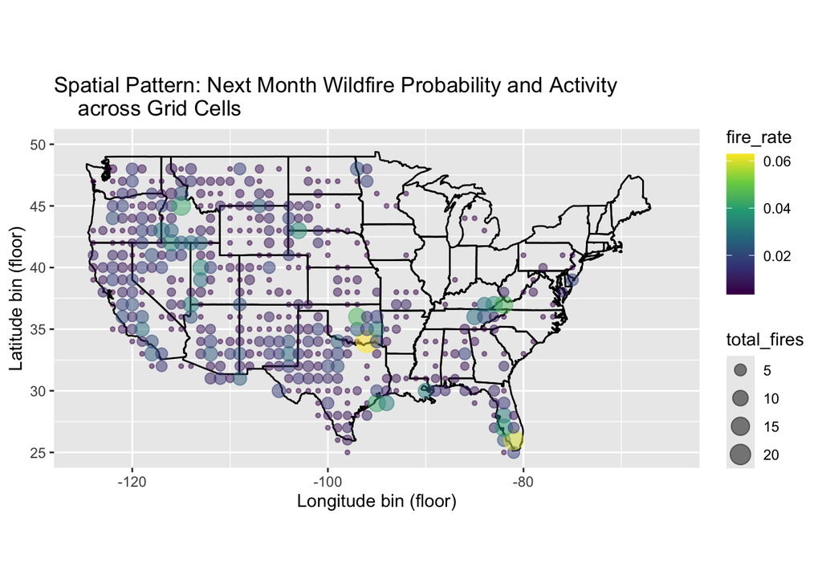

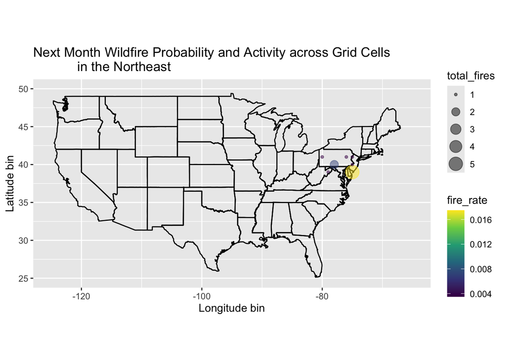

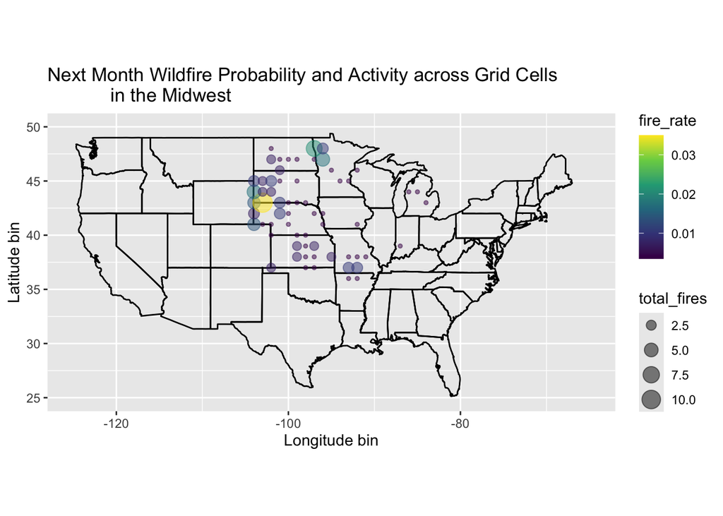

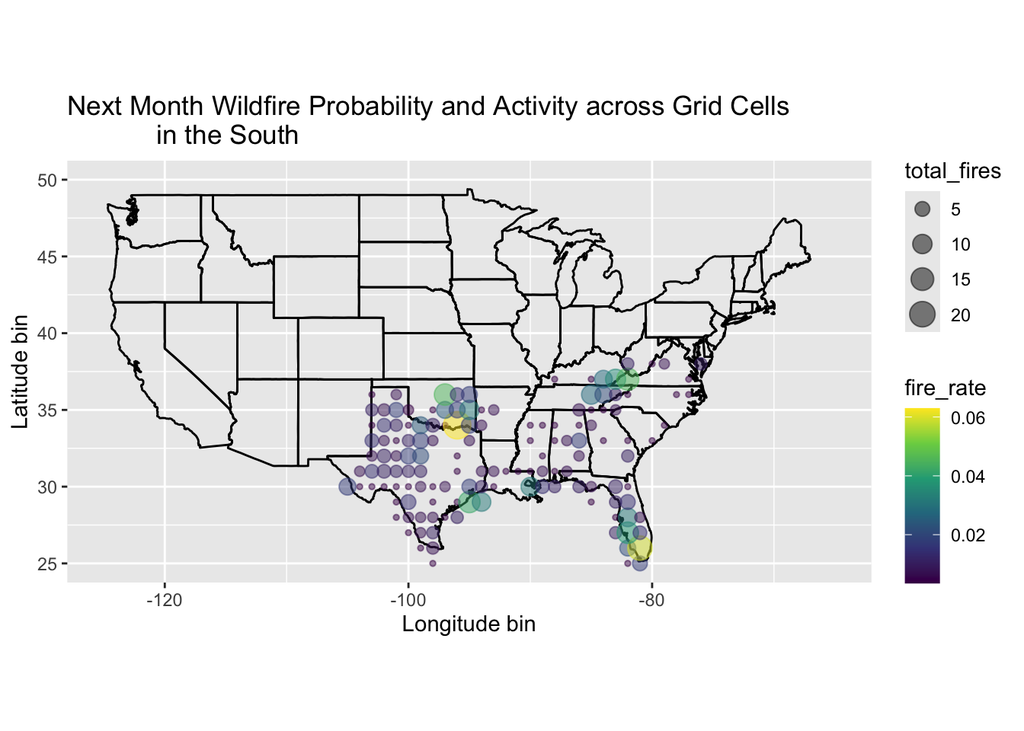

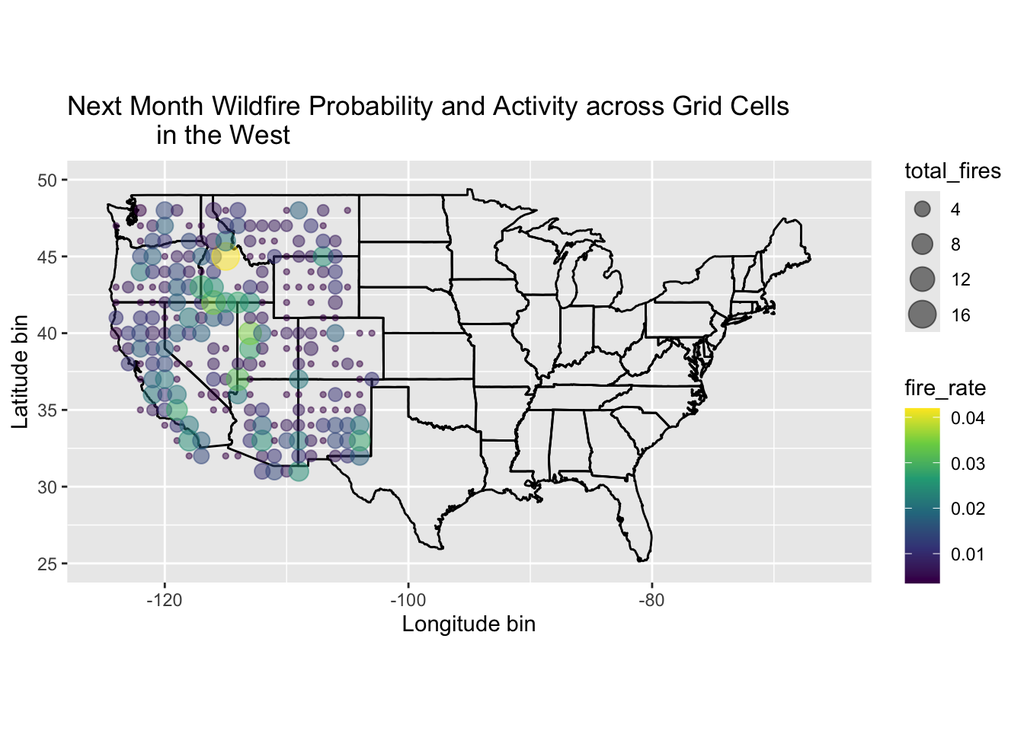

The spatial pattern plot highlights wildfire activity in each grid cell based on the mean probability that a notable wildfire will occur next month and the total number of wildfires. Each point is placed on a the longitude and latitude panel with the color of the point indicating how high the chance is that a notable wildfire will occur in that location next month and the size representing how many wildfires have taken place in that location over time. This visualization indicates wildfire risk and frequency based on geographic location. According to the plot, there is a higher likelihood of notable wildfires occurring in the western and southern parts of the US. For instance, there is a high wildfire risk and high wildfire activity taking place in states like Florida, California, and Texas. On the other hand, states in the Northeast and Midwest do not seem to have a high frequency or risk of wildfires. Additionally, the plot portrays that wildfire risk is scattered throughout the US, which provides reasoning for including spatial information into the model. Also, there are obvious clusters of wildfires in certain areas, which means there are underlying complex nonlinear relationships between the predictor variables that need to be addressed with a flexible and dynamic model, such as XGBoost.

#### EDA Plot 2: Temporal Pattern

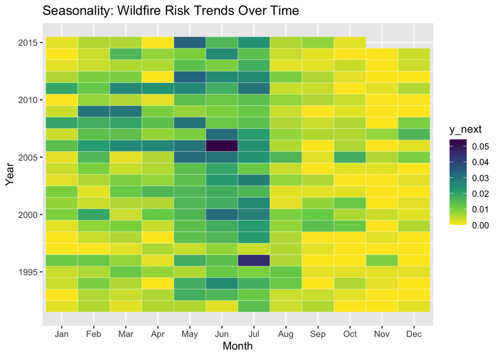

The temporal pattern plot is a heatmap that highlights the seasonal pattern of wildfire risk across various years and months. Each cell indicates the probability that a wildfire will occur in the next month for the year and month pair. The darker cells represent a higher chance of wildfire activity while lighter cells indicate a lower chance of wildfire activity. It is evident from the plot that certain months have higher wildfire risk throughout most years in the data set. For instance, May, June, and July show high wildfire risk while October, November, and December portray low wildfire risk consistently. These trends may be due to certain months having higher temperatures and drier conditions that leads to a higher risk of wildfire occurrence. Moreover, there are distinct patterns in the heatmap, but there is also variability in wildfire risk across the years since some years have a much higher likelihood than other years, like 2006 and 1996, for example. The higher chance of wildfire activity in certain months emphasizes the importance of including seasonality and temporal trends in the model. Since the wildfire risk varies throughout the year, the model will have to account for the periodic seasonal trends and recurring temporal patterns happening during certain months. The plot makes it clear that the wildfire risks varies across various months and years, suggesting a nonlinear relationship between predictors. Thus, a model such an XGBoost model would be able to capture the complex interactions between the seasonal variables and historical fire occurrences.

### 3. Modeling

There will be two models fit on the wildfire data: the baseline model with logistic regression and an XGBoost model.

#### Baseline Model

The first model that will be fit on the data is the baseline model. This model will be logistic regression because it works well for binary prediction where the outcome is either notable wildfire activity occurring in the following month or not. Moreover, this baseline model will be simple and easy to interpret especially in terms of the outcome variable, `y_next`, which represents whether a notable fire will occur in a grid cell for the next month. The baseline logistic regression model assumes that the predictors have a linear relationship with the log-odds of wildfire incidence, so this may not be the best model for the data considering that the EDA shows more complex interactions between predictors. Here are the variables as a part of the dataset that will be used in the model and the baseline equation:

```
## Rows: 147,576
## Columns: 20
## $ y_next               <fct> 0, 0, 0, 0, 0, 0, 0, 0, 0, 0, 0, 0, 0, 0, 0, 0, 0…
## $ lat_bin              <dbl> 17, 17, 17, 17, 17, 17, 17, 17, 17, 17, 17, 17, 1…
## $ lon_bin              <dbl> -67, -67, -67, -67, -67, -67, -67, -67, -67, -67,…
## $ state                <fct> PR, PR, PR, PR, PR, PR, PR, PR, PR, PR, PR, PR, P…
## $ month_cos            <dbl> 8.660254e-01, 5.000000e-01, 6.123234e-17, -5.0000…
## $ month_sin            <dbl> 5.000000e-01, 8.660254e-01, 1.000000e+00, 8.66025…
## $ year                 <dbl> 1992, 1992, 1992, 1992, 1992, 1992, 1992, 1992, 1…
## $ n_fires              <int> 0, 0, 0, 0, 0, 0, 0, 0, 0, 0, 0, 0, 0, 0, 0, 0, 0…
## $ fire_lag12           <int> 0, 0, 0, 0, 0, 0, 0, 0, 0, 0, 0, 0, 0, 0, 0, 0, 0…
## $ fire_roll3           <int> 0, 0, 0, 0, 0, 0, 0, 0, 0, 0, 0, 0, 0, 0, 0, 0, 0…
## $ fire_roll12          <int> 0, 0, 0, 0, 0, 0, 0, 0, 0, 0, 0, 0, 0, 0, 0, 0, 0…
## $ size_roll3           <dbl> 0, 0, 0, 0, 0, 0, 0, 0, 0, 0, 0, 0, 0, 0, 0, 0, 0…
## $ size_roll12          <dbl> 0, 0, 0, 0, 0, 0, 0, 0, 0, 0, 0, 0, 0, 0, 0, 0, 0…
## $ natural_fires        <int> 0, 0, 0, 0, 0, 0, 0, 0, 0, 0, 0, 0, 0, 0, 0, 0, 0…
## $ human_fires          <int> 0, 0, 0, 0, 0, 0, 0, 0, 0, 0, 0, 0, 0, 0, 0, 0, 0…
## $ infrastructure_fires <int> 0, 0, 0, 0, 0, 0, 0, 0, 0, 0, 0, 0, 0, 0, 0, 0, 0…
## $ avg_fire_duration    <dbl> 0, 0, 0, 0, 0, 0, 0, 0, 0, 0, 0, 0, 0, 0, 0, 0, 0…
## $ federal_fires        <int> 0, 0, 0, 0, 0, 0, 0, 0, 0, 0, 0, 0, 0, 0, 0, 0, 0…
## $ private_fires        <int> 0, 0, 0, 0, 0, 0, 0, 0, 0, 0, 0, 0, 0, 0, 0, 0, 0…
## $ public_fires         <int> 0, 0, 0, 0, 0, 0, 0, 0, 0, 0, 0, 0, 0, 0, 0, 0, 0…
```

[output not shown]

The equation for the logistic regression model is as follows:
$$\log\left(\frac{P(y_{next}=1)}{1 - P(y_{next}=1)}\right)
=
\beta_0 +
\beta_1 lat_{bin} +
\beta_2 lon_{bin} +
\beta_3 state +
\beta_4 month_{cos} +
\beta_5 month_{sin} +
\beta_6 year +
\beta_7 n\_fires +
\beta_8 fire\_lag12 +
\beta_9 fire\_roll3 +
\beta_{10} fire\_roll12 +
\beta_{11} size\_roll3 +
\beta_{12} size\_roll12 +
\beta_{13} natural\_fires +
\beta_{14} human\_fires +
\beta_{15} infrastructure\_fires +
\beta_{16} avg\_fire\_duration +
\beta_{17} federal\_fires +
\beta_{18} private\_fires +
\beta_{19} public\_fires$$

Essentially, the log-odds of the wildfire risk in the next month are modeled as a linear combination of all the predictor variables.

#### Gradient Boosting Model

The other model used will be an XGBoost model in order to more dynamically predict wildfire risk. The XGBoost model is well suited for this task because it will capture the underlying non-linear patterns and interactions between the predictors in the data, unlike logistic regression which assumes that there is a linear relationship between the predictors. The exploratory data analysis revealed that there is spatial clustering of wildfire incidence in certain geographic locations and the wildfires exhibit seasonal patterns or cycles that occur over several years and months. Therefore, the relationship between predictors is nonlinear and interactions that may not be accounted for in a simple logistic regression model. The XGBoost procedure constructs several decision trees and each new tree improves upon the mistakes of the previous trees. Therefore, the model will be able to capture the complex, non-linear interactions among predictors to improve the predictive accuracy. For the XGBoost model, the number of trees will be 100, which ensures that the model will not overfit or underfit by building too many or too few trees. The learning rate, which indicates the contribution level of each new tree in the model, will be 0.1. This is a small number that ensures that the model will allow for a higher accuracy by learning at a slower rate to reach the highest optimization of model fit. Lastly, the maximum depth value represents the number of times a tree is allowed to split before a prediction is made. Therefore, the maximum depth value will be 3 because the small value ensures that the model is learning the general patterns in the data and not overfitting.

The gradient boosting model aims to minimize the following function:
$$L = \sum_{i=1}^{n} l(y_i, \hat{y}_i) + \sum_{k=1}^{K} \Omega(f_k)$$
For the XGBoost equation, the loss function is represented as L, the predicted probability is ŷi, and Ω(fk) is the regularization term that ensures that additional trees are penalized so the model does not overfit the data. The XGBoost model will iteratively add more trees to minimize this function, which will allow it to capture the underlying nonlinear trends in the wildfire data and allow the model to make accurate predictions

### 4. Model Fitting and Validation

The two models that will be used for fitting and validation are logistic regression (baseline model) and XGBoost. Due to wildfire activity changing over time, the models are evaluated using a time aware validation approach. In other words, the models are trained with all records up until a given year and then they are used to predict wildfire activity in the following year. This process is repeated across several years to determine how well the model is able to generalize to future wildfire incidence. Then, the model will be evaluated with the Area under the ROC Curve (AUC). This reveals how well the model is able to determine distinctly which months have notable wildfires and which months do not. The model with the higher AUC will have a higher predictive power of next month wildfire activity. Here are the results of the time-aware cross validation for both models with the outptted AUC performance by train and validation year:

```
## # A tibble: 20 × 4
##    train_end_year valid_year auc_glm auc_xgb
##             <dbl>      <dbl>   <dbl>   <dbl>
##  1           1994       1995   0.668   0.750
##  2           1995       1996   0.717   0.811
##  3           1996       1997   0.825   0.831
##  4           1997       1998   0.758   0.811
##  5           1998       1999   0.667   0.703
##  6           1999       2000   0.731   0.808
##  7           2000       2001   0.753   0.822
##  8           2001       2002   0.724   0.788
##  9           2002       2003   0.694   0.785
## 10           2003       2004   0.668   0.805
## 11           2004       2005   0.660   0.742
## 12           2005       2006   0.665   0.692
## 13           2006       2007   0.648   0.742
## 14           2007       2008   0.615   0.720
## 15           2008       2009   0.669   0.763
## 16           2009       2010   0.658   0.724
## 17           2010       2011   0.662   0.724
## 18           2011       2012   0.636   0.712
## 19           2012       2013   0.702   0.802
## 20           2013       2014   0.738   0.824
```

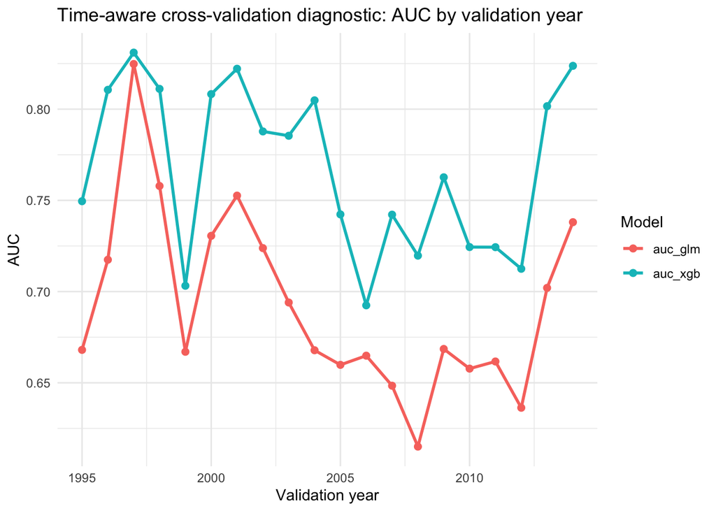

The AUC plot reveals how the logistic regression baseline model and XGBoost model performed across various validation years using time-aware validation. According to the plot, for all validation years, the XGBoost model outperforms the logistic regression model since the AUC values are higher for each year. Moreover, the AUC values are between 0.69 and 0.83 for the XGBoost model while the AUC values are between 0.62 and 0.82 for the logistic regression model. Since the XGBoost model has a smaller range of AUC values and higher values in general, it indicates a greater predictive accuracy. In other words, the XGBoost model is better at separating between cases of notable wildfires and no notable wildfires. The improvement in the AUC values suggests that the nonlinear structure of the wildfire data is better understood by the XGBoost model. It is evident that the XGBoost model provides more accurate and consistent predictions of wildfire activity in the next month, in comparison to the baseline logistic regression model.

```
## The percentage improvement of the model performance for the XGBoost model in comparison to the baseline logistic regression is 10.84878 percent
```

#### ROC Plots

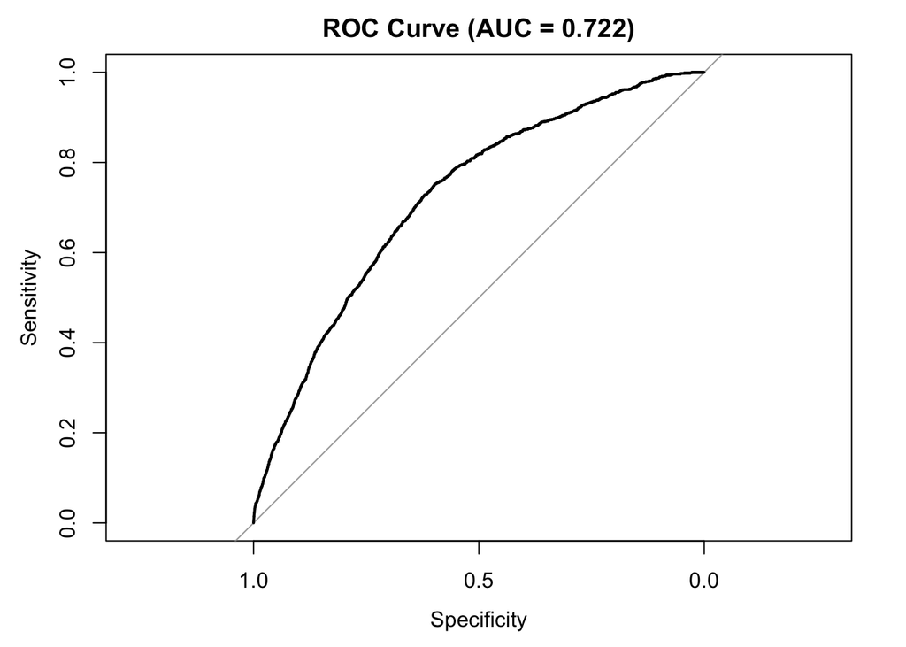

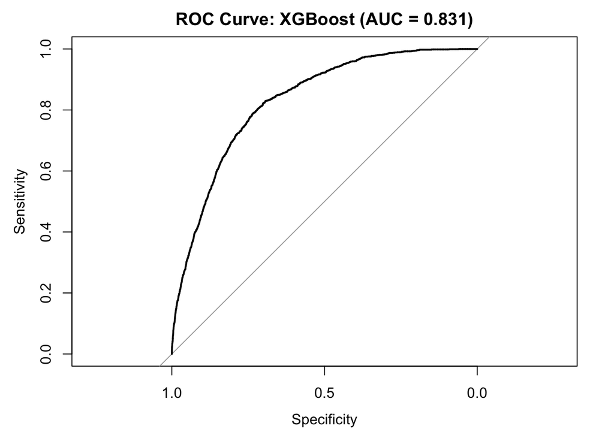

### 5. Summary

Overall, the aim of this project was to develop predictive models that forecast the probability of a wildfire occurring in the following month for each geographic cell in the US. First, the wildfire dataset was pre-processed to capture temporal and spatial patterns. Then the dataset was rendered to have a binary indicator output depicting whether a wildfire would occur in the next month and the baseline predictor variables were constructed. The final predictors used in the model are `y_next`, `lat_bin`, `lon_bin`, `state`,`month_cos`, `month_sin`, `year`, `n_fires`, `fire_lag12`, `fire_roll3`, `fire_roll12`, `size_roll3`, `size_roll12`, `natural_fires`, `human_fires`, `infrastructure_fires`, `avg_fire_duration`, `federal_fires`, `private_fires`, `public_fires`. After the data set was pre-processed and analyzed, exploratory data analysis was conducted. This step revealed clear spatial and seasonal trends in wildfire activity. Notably, there was high wildfire activity in the Western and Southern regions on the US. The heatmap indicated cylical, seasonal patterns with a higher chance of wildfire incidence during summer months, like June and July. The EDA plots highlighted that the relationship between the predictors is non-linear and complex.

Based on this information, two models were constructed: a baseline model of logistic regression, and a gradient boosting model (XGBoost). The model was trained on data from all years up until a certain year, and that year was used for validation. This way, there is no data leakage, in order to ensure that future data is not used to predict past events. The model performance was evaluated using time-aware validation, Area Under the ROC Curve (AUC), and the ROC curve. The XGBoost model outperformed the logistic regression model since the AUC for the XGBoost model is 0.831 while the AUC for the baseline model is 0.722. The XGBoost model improves the AUC by approximately 10.85% more than the logistic regression model. Since logistic regression assumes that the predictors have a linear relationship, it is not the best predictive model for wildfire data, which reveals complex interactions among predictors. Furthermore, the ROC curve confirms that the XGBoost model more accurately differentiates between months that have and do not have notable wildfires. These results suggest that more flexible and dynamic models like XGBoost are better suited for wildfire prediction because they are able to understand the complex spatial and temporal trends that affect wildfire activity. Through these predictive models, we can be better informed about strategies for wildfire prevention and monitoring while acknowledging when to take action.

### R Appendix

```r
knitr::opts_chunk$set(echo = TRUE)
#Loading necessary libraries
library(tidyverse)
library(maps) # for map data
library(lubridate) # for working with dates
library(viridis) # for color scales
library(pROC) # for the ROC Curve
library(xgboost) # for the XGBoost Model
library(Matrix) # for creating a matrix for the XGBoost Model

wildfires <-read.csv(file = "./Data/wildfires_sample_100k.csv") %>%
  select(FIRE_YEAR, DISCOVERY_DOY, FIRE_SIZE, LATITUDE, LONGITUDE, STATE, STAT_CAUSE_DESCR, CONT_DOY, OWNER_DESCR) %>%
  mutate(STATE = as.factor(STATE))

glimpse(wildfires)

#Create the FIRE_DATE variable and extract the year and month
fires <- wildfires %>%
    mutate(FIRE_DATE = as.Date(paste(FIRE_YEAR, DISCOVERY_DOY, sep = "-"), format = "%Y-%j"),
          YEAR = year(FIRE_DATE),
          MONTH = month(FIRE_DATE))

#Define notable fire threshold
notable_threshold_acres <- 300

#filter dataset to only notable fires
notable_fires <- fires %>%
  filter(FIRE_SIZE >= notable_threshold_acres)

cat("Number of notable fires:", nrow(notable_fires))
#Creating grid IDs and month index
notable_fires <- notable_fires %>%
  mutate(
    lat_bin = floor(LATITUDE),
    lon_bin = floor(LONGITUDE),
    ym = YEAR * 100 + MONTH   # e.g., 201507
  )

#Fire indicator at (grid, month)
grid_month_fire <- notable_fires %>%
  group_by(lat_bin, lon_bin, ym) %>%
  summarise(n_fires = n(), fire_this_month = 1, .groups = "drop")

head(grid_month_fire)
#Building the panel of all grid cells that appear at least once
all_grids <- grid_month_fire %>% distinct(lat_bin, lon_bin)

#Generating a safe monthly sequence using actual dates
start_date <- ymd(paste0(min(grid_month_fire$ym) %/% 100, "-", min(grid_month_fire$ym) %% 100, "-01"))
end_date   <- ymd(paste0(max(grid_month_fire$ym) %/% 100, "-", max(grid_month_fire$ym) %% 100, "-01"))

all_months <- tibble(date = seq.Date(start_date, end_date, by = "month")) %>%
  mutate(year = year(date), month = month(date), ym = year * 100 + month) %>%
  select(ym, year, month)

#Creating every possible grid cell and month combination and adding that information to the grid_month_fire data set
panel <- crossing(all_grids, all_months) %>%
  left_join(grid_month_fire, by = c("lat_bin", "lon_bin", "ym")) %>%
  mutate(
    n_fires = replace_na(n_fires, 0),
    fire_this_month = replace_na(fire_this_month, 0)
  )

glimpse(panel)
#Creating the binary indicator variable
panel <- panel %>%
  arrange(lat_bin, lon_bin, ym) %>%
  group_by(lat_bin, lon_bin) %>%
  mutate(
    y_next = lead(fire_this_month, n = 1L)
  ) %>%
  ungroup() %>%
  filter(!is.na(y_next))

table(panel$y_next)
# Function that counts the frequency of each state and returns the maximum value
mode_state <- function(x) {
  names(which.max(table(x)))
}

#Determining the majority state for each grid cell
grid_state <- notable_fires %>%
  group_by(lat_bin, lon_bin) %>%
  summarise(
    state = as.factor(mode_state(STATE)),
    .groups = "drop"
  )

#Add the state to the data set and output the summary statistics
panel <- panel %>%
  left_join(grid_state, by = c("lat_bin","lon_bin"))

panel %>% select(state) %>% summary
#Months are converted into sine and cosine
panel <- panel %>%
  mutate(
    month_sin = sin(2 * pi * month / 12),
    month_cos = cos(2 * pi * month / 12)
  )

#Output the month_sin and month_cos
panel %>% select('month_sin', 'month_cos') %>% head
#Calculating the average fire size if there are multiple that appear within a (grid, month)
grid_fire_size <- notable_fires %>%
  group_by(lat_bin, lon_bin, ym) %>%
  summarize(
    fire_size = mean(FIRE_SIZE, na.rm = TRUE),
    .groups = "drop"
  )

#Join the grid_fire_size with the panel data set
panel <- panel %>%
  left_join(grid_fire_size, by = c("lat_bin","lon_bin", "ym")) %>%
  mutate(fire_size = coalesce(fire_size, 0))

#Function that calculates the rolling sum for size k
rolling_sum <- function(x, k) {
  output <- c()
  for (i in 1:length(x)) {
    max_value <- max(1, i-k+1)
    output[i] <- sum(x[max_value:i], na.rm = TRUE)
  }
  output
}

#Constructing the lag and roll predictors
panel <- panel %>%
  arrange(lat_bin, lon_bin, ym) %>%
  group_by(lat_bin, lon_bin) %>%
  mutate(
    fire_lag12  = replace_na(lag(n_fires, 12), 0),
    fire_roll3  = rolling_sum(n_fires, 3),
    fire_roll12 = rolling_sum(n_fires, 12),
    size_roll3  = rolling_sum(fire_size, 3),
    size_roll12 = rolling_sum(fire_size, 12),
  ) %>%
  ungroup()

#Select the required variables and output the summary
panel %>%
  select("n_fires", "fire_lag12", "fire_roll3", "fire_roll12",
         "size_roll3", "size_roll12") %>%
  summary


#Observe what are the causes of the wildfires
unique(wildfires$STAT_CAUSE_DESCR)

#Determine which causes fall under which category and add it to the data set
notable_fires <- notable_fires %>%
  mutate(
    cause = case_when(
      STAT_CAUSE_DESCR == "Lightning" ~ "Natural",
      STAT_CAUSE_DESCR %in% c("Campfire", "Debris Burning", "Smoking", "Children", "Equipment Use", "Arson") ~ "Human",
      STAT_CAUSE_DESCR %in% c("Powerline", "Railroad", "Structure") ~ "Infrastructure",
      TRUE ~ "Other"
    ),
    cause = as.factor(cause)
  )

#Convert the causes into counts for each (grid, month)
grid_cause <- notable_fires %>%
  group_by(lat_bin, lon_bin, ym) %>%
  summarize(
    natural_fires = sum(cause == "Natural"),
    human_fires = sum(cause == "Human"),
    infrastructure_fires = sum(cause == "Infrastructure"),
    .groups = "drop"
  )

#Merge grid_cause with the panel
panel <- panel %>%
  left_join(grid_cause, by = c("lat_bin", "lon_bin", "ym")) %>%
  mutate(
    natural_fires = replace_na(natural_fires, 0),
    human_fires = replace_na(human_fires, 0),
    infrastructure_fires = replace_na(infrastructure_fires, 0),
  )

#Output the summary statistics
panel %>%
  select("natural_fires", "human_fires", "infrastructure_fires") %>%
  summary
#Construct CONT_DATE using CONT_DOY
notable_fires <- notable_fires %>%
  mutate(CONT_DATE = as.Date(paste(FIRE_YEAR, CONT_DOY, sep = "-"), format = "%Y-%j"))
```

```r
#Calculate the duration of the fire using FIRE_DATE
notable_fires <- notable_fires %>%
  mutate(fire_duration = as.numeric(CONT_DATE - FIRE_DATE))

#Calculate the average fire duration
grid_duration <- notable_fires %>%
  group_by(lat_bin, lon_bin, ym) %>%
  summarize(
    avg_fire_duration = mean(fire_duration, na.rm = TRUE),
    .groups = "drop"
  )

#Merge grid_duration into the panel data set
panel <- panel %>%
  left_join(grid_duration, by = c("lat_bin", "lon_bin", "ym")) %>%
  mutate(avg_fire_duration = replace_na(avg_fire_duration, 0))

#Output the summary statistics
panel %>%
  select("avg_fire_duration") %>%
  summary
#Observe which are the different types of land owners
unique(wildfires$OWNER_DESCR)

#Categorize each ownership type into public, private, and federal
notable_fires <- notable_fires %>%
  mutate(
    ownership = case_when(
      OWNER_DESCR %in% c("USFS","BLM","NPS","FWS","BOR",
                         "OTHER FEDERAL","UNDEFINED FEDERAL") ~ "Federal",

      OWNER_DESCR %in% c("PRIVATE","STATE OR PRIVATE") ~ "Private",

      OWNER_DESCR %in% c("STATE","COUNTY","MUNICIPAL/LOCAL",
                         "BIA","TRIBAL") ~ "Public",

      TRUE ~ "Other"
    ),
    ownership = as.factor(ownership)
  )

#Convert the ownership types into counts for each (grid, month)
grid_ownership <- notable_fires %>%
  group_by(lat_bin, lon_bin, ym) %>%
  summarize(
    federal_fires = sum(ownership == "Federal"),
    private_fires = sum(ownership == "Private"),
    public_fires = sum(ownership == "Public"),
    .groups = "drop"
  )

#Merge grid_ownership with the panel
panel <- panel %>%
  left_join(grid_ownership, by = c("lat_bin","lon_bin","ym")) %>%
  mutate(
    federal_fires = replace_na(federal_fires, 0),
    private_fires = replace_na(private_fires, 0),
    public_fires = replace_na(public_fires, 0)
  )

#Output the summary statistics for the selected variables
panel %>%
  select(federal_fires, private_fires, public_fires) %>%
  summary()
#Creating the dataset summary table
dataset_summary <- tibble(
  Number_Rows = nrow(panel),
  Min_Year = min(panel$year),
  Max_Year = max(panel$year),
  Space_Unit = "1° x 1° lat-lon grid (floor bins)",
  Time_Unit = "monthly",
  Outcome = "If any notable fire occurs in grid cell next month, y_next = 1 and otherwise y_next = 0",
  Predictors = "lat_bin, lon_bin, state, month_cos, month_sin, year, n_fires, fire_lag12, fire_roll3, fire_roll12, size_roll3, size_roll12, natural_fire, human_fire, infrastructure_fire, avg_fire_duration, federal_fire, public_fire, private_fire"
)
knitr::kable(dataset_summary)
#Grouping wildfires by region
panel <- panel %>%
  mutate(region = case_when(
    state %in% c("CT","ME","MA","NH","RI","VT","NJ","NY","PA") ~ "Northeast",
    state %in% c("IL","IN","MI","OH","WI", "IA","KS","MN","MO","NE","ND","SD") ~ "Midwest",
    state %in% c("DE","DC","FL","GA","MD","NC","SC","VA","WV", "AL","KY","MS","TN", "AR","LA","OK","TX") ~ "South",
    state %in% c("AZ","CO","ID","MT","NV","NM","UT","WY","AK","CA","HI","OR","WA") ~ "West",
    TRUE ~ "Other"
  ))

#Creating a data frame with the fire rate, total number of fires, and number of observations
eda_spatial <- panel %>%
  group_by(lat_bin, lon_bin, region) %>%
  summarise(
    fire_rate = mean(y_next),
    total_fires = sum(n_fires),
    observations = n(),
    .groups = "drop"
  )

#Creating the plot that shows the next month wildfire activity for the US
map_info <- map_data("state")
ggplot(eda_spatial, mapping = aes(x = lon_bin, y = lat_bin)) +
  coord_quickmap(xlim = c(-125, -65), ylim = c(25, 50)) +
  geom_polygon(data = map_info, mapping = aes(x = long, y = lat, group = group), fill = NA, color = "black") +
  geom_point(mapping = aes(color = fire_rate, size = total_fires), alpha = 0.5) +
  scale_color_viridis_c() +
  labs(
    title = "Spatial Pattern: Next Month Wildfire Probability and Activity
    across Grid Cells", x = "Longitude bin (floor)", y = "Latitude bin (floor)", fill = "Mean y_next"
  )

#Creating a function to generate a plot for each region in the US
plot_region <- function(region_name, plot_title) {
  eda_spatial %>%
    filter(region == region_name) %>%
    ggplot(mapping = aes(x = lon_bin, y = lat_bin)) +
    coord_quickmap(xlim = c(-125, -65), ylim = c(25, 50)) +
    geom_polygon(data = map_info, mapping = aes(x = long, y = lat, group = group), fill = NA, color = "black") +
    geom_point(mapping = aes(color = fire_rate, size = total_fires),
      alpha = 0.5
    ) +
    scale_color_viridis_c() +
    labs(title = plot_title, x = "Longitude bin", y = "Latitude bin", fill = "Mean y_next")
}

#Generate plots for each region
plot_region("Northeast", "Next Month Wildfire Probability and Activity across Grid Cells
            in the Northeast")
plot_region("Midwest", "Next Month Wildfire Probability and Activity across Grid Cells
            in the Midwest")
plot_region("South", "Next Month Wildfire Probability and Activity across Grid Cells
            in the South")
plot_region("West", "Next Month Wildfire Probability and Activity across Grid Cells
            in the West")
#Creating the eda_month data frame
eda_month <- panel %>%
  group_by(month, year) %>%
  summarize(
    mean_y_next = mean(y_next),
    .groups = "drop"
  )

#Converting the numbers into month names
eda_month <- eda_month %>%
  mutate(month_name = case_when(
    month == 1  ~ "Jan",
    month == 2  ~ "Feb",
    month == 3  ~ "Mar",
    month == 4  ~ "Apr",
    month == 5  ~ "May",
    month == 6  ~ "Jun",
    month == 7  ~ "Jul",
    month == 8  ~ "Aug",
    month == 9  ~ "Sep",
    month == 10 ~ "Oct",
    month == 11 ~ "Nov",
    month == 12 ~ "Dec"
  )) %>%
  mutate(month_name = factor(month_name, levels = c("Jan","Feb","Mar","Apr","May","Jun", "Jul","Aug","Sep","Oct","Nov","Dec")))

#Heatmap that shows the next month wildfire risk for each year and month
ggplot(eda_month, mapping = aes(x = month_name, y = year, fill = mean_y_next)) +
  geom_tile(color = "white") +
  scale_fill_viridis_c(name = "y_next", direction = -1) +
  labs(
    title = "Seasonality: Wildfire Risk Trends Over Time", x = "Month", y = "Year"
  )
#Creating the baseline logistic regression model
model_df <- panel %>%
  mutate(y_next = factor(y_next, levels = c(0, 1))) %>%
  select(y_next, lat_bin, lon_bin, state,
         month_cos, month_sin, year,
         n_fires, fire_lag12, fire_roll3, fire_roll12, size_roll3, size_roll12, natural_fires, human_fires, infrastructure_fires, avg_fire_duration, federal_fires, private_fires, public_fires)
glimpse(model_df)
```

```r
cat("The baseline equation will be: y_next ~ lat_bin + lon_bin + state + month_cos + month_sin + year + n_fires + fire_lag12 + fire_roll3 + fire_roll12 + size_roll3 + size_roll12")

#Model fitting for logistic regression and XGBoost
years_sorted <- sort(unique(model_df$year))
min_train_years <- 3

#Determining the model formula
feat_formula <- y_next ~ lat_bin + lon_bin + month_cos + month_sin + year + state + n_fires + fire_lag12 + fire_roll3 + fire_roll12 + size_roll3 + size_roll12 + natural_fires + human_fires + infrastructure_fires + avg_fire_duration + federal_fires + private_fires + public_fires
features <- c("lat_bin", "lon_bin", "month_cos", "month_sin", "year", "state", "n_fires", "fire_lag12", "fire_roll3", "fire_roll12", "size_roll3", "size_roll12", "natural_fires", "human_fires", "infrastructure_fires", "avg_fire_duration", "federal_fires", "private_fires", "public_fires")
target <- "y_next"

fold_results <- tibble(
    train_end_year = years_sorted[(min_train_years):(length(years_sorted) - 2)],
    valid_year = years_sorted[(min_train_years + 1):(length(years_sorted) - 1)]) %>%
  mutate(
      # Logistic Regression
      auc_glm = map2_dbl(train_end_year, valid_year, function(tr_end, va_year) {
          train <- model_df %>% filter(year <= tr_end)
          valid <- model_df %>% filter(year == va_year)
          fit <- glm(feat_formula, data = train, family = "binomial")
          p_hat_glm <- predict(fit, newdata = valid, type = "response")
          roc_obj <- roc(response = valid$y_next, predictor = p_hat_glm, quiet = TRUE)
          as.numeric(auc(roc_obj))
      }),
      # XGBoost
      auc_xgb = map2_dbl(train_end_year, valid_year, function(tr_end, va_year) {
          train <- model_df %>% filter(year <= tr_end)
          valid <- model_df %>% filter(year == va_year)
          train$y_next_num <- as.numeric(as.character(train$y_next))
          valid$y_next_num <- as.numeric(as.character(valid$y_next))
          #Predictor Matrix for training and validation and DMatrix for XGBoost model
          train_x <- data.matrix(train[, features])
          valid_x <- data.matrix(valid[, features])
          dtrain <- xgb.DMatrix(data = train_x, label = train$y_next_num)
          fit <- xgb.train(data = dtrain, label = as.double(train$y_next_num), objective = "binary:logistic", nrounds = 100, max_depth = 3, eta = 0.1, verbose = 0)
          p_hat_xgb <- predict(fit, newdata = valid_x)
          roc_xgb <- roc(response = valid$y_next_num, predictor = p_hat_xgb, quiet = TRUE)
          as.numeric(auc(roc_xgb))
      })
  )
fold_results

#Plotting the AUC Plots for Logistic Regression and XGBoost
fold_long <- fold_results %>%
  pivot_longer(
    cols = c(auc_glm, auc_xgb),
    names_to = "model",
    values_to = "auc"
  )

ggplot(fold_long, aes(x = valid_year, y = auc, color = model)) +
  geom_line(linewidth = 1) +
  geom_point(size = 2) +
  labs(
    title = "Time-aware cross-validation diagnostic: AUC by validation year",
    x = "Validation year",
    y = "AUC",
    color = "Model"
  ) +
  theme_minimal()
#Calculating percent improvement in AUC between the baseline and XGBoost
mean_glm <- mean(fold_results$auc_glm)
mean_xgb <- mean(fold_results$auc_xgb)
percent <- (mean_xgb - mean_glm) / mean_glm * 100
cat("The percentage improvement of the model performance for the XGBoost model in comparison to the baseline logistic regression is", percent, "percent")
#ROC curve for logistic regression
fit_glm <- glm(feat_formula, data = model_df, family = "binomial")
p_hat <- predict(fit_glm, type = "response")
roc_obj <- roc(model_df$y_next, p_hat, quiet = TRUE)
plot.roc(roc_obj, main = paste0("ROC Curve (AUC = ", round(auc(roc_obj),3), ")"))

# XGBoost ROC
model_df$y_next_num <- as.numeric(as.character(model_df$y_next))
train_x <- data.matrix(model_df[, features])
dtrain <- xgb.DMatrix(data = train_x, label = model_df$y_next_num)
fit_xgb <- xgb.train(data = dtrain, objective = "binary:logistic", nrounds = 100, max_depth = 3, eta = 0.1, verbose = 0)
p_hat_xgb <- predict(fit_xgb, newdata = train_x)
roc_xgb <- roc(model_df$y_next_num, p_hat_xgb, quiet = TRUE)
plot.roc(roc_xgb, main = paste0("ROC Curve: XGBoost (AUC = ", round(auc(roc_xgb), 3), ")")
)
```